## Overview

Concordance analysis allows us to group strains that are genetically almost identical into an isotype. The following table summarizes the number of isotypes from previous and current releases, and the number of strains that belong to those isotypes.

|  | **Isotypes** | **Strains Included** | **Strains with WGS data** | **Strains with RAD-seq data** |
| --- | --- | --- | --- | --- |
| **Isotypes from Previous Release** | 400 | 968 | 828 | 140 |
| **New Isotypes from Current Release** | 101 | 254 | 254 | 0 |
| **Total** | 501 | 1222 | 1082 | 140 |

## Concordance score distribution and cutoff

We examined the pairwise concordance scores of all strains. Concordance values for every pair of strains were calculated as the number of shared SNVs divided by the total number of SNVs called for each pair. If the concordance score was more than 0.9997, the strain pair is grouped into the same isotype.

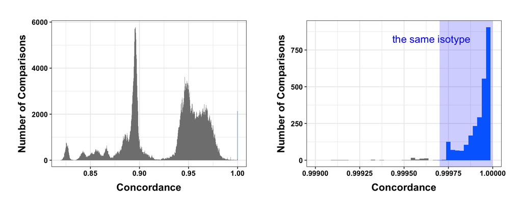

## Search for concordance for strain pairs

Strain comparisons are listed in the table below. Only concordance scores > 0.9995 are shown.

| Strain | Strain | Total variants | Diff variants | Concordance | Is isotype |
| --- | --- | --- | --- | --- | --- |
| BRC20113 | BRC20067 | 2805105 | 72 | 0.999974332511617 | True |
| ECA1071 | ECA1070 | 2814362 | 86 | 0.999969442452677 | True |
| ECA1072 | ECA1070 | 2795035 | 83 | 0.999970304486348 | True |
| ECA1072 | ECA1071 | 2826983 | 87 | 0.999969225142139 | True |
| ECA1073 | ECA1070 | 2806690 | 66 | 0.999976484756065 | True |
| ECA1073 | ECA1071 | 2838903 | 66 | 0.99997675158327 | True |
| ECA1073 | ECA1072 | 2819978 | 59 | 0.999979077850962 | True |
| ECA1074 | ECA1070 | 2814907 | 93 | 0.999966961608323 | True |
| ECA1074 | ECA1071 | 2849109 | 60 | 0.999978940784645 | True |
| ECA1074 | ECA1072 | 2826962 | 92 | 0.999967456230399 | True |

[output cut: 2676 more lines]

## Changes from previous release

- This release used only SNVs for isotype assignment.
- Strains ECA1465, ECA1467, ECA1493, ECA1515 were each their own isotype in 20200815 release. They were grouped into the same isotype in this release, which resulted in a reduce of count of previous isotypes from 403 to 400. Below is their pairwise concordance value in this release (top) and in 20200815 release (bottom).

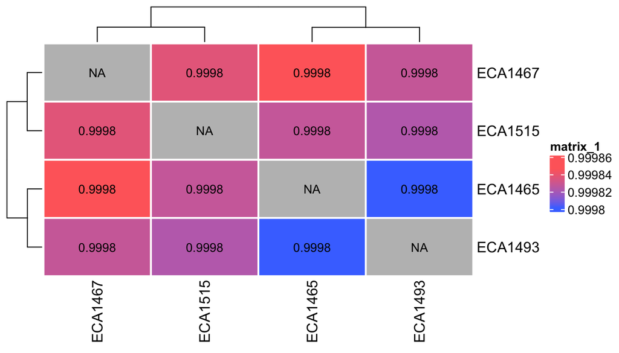

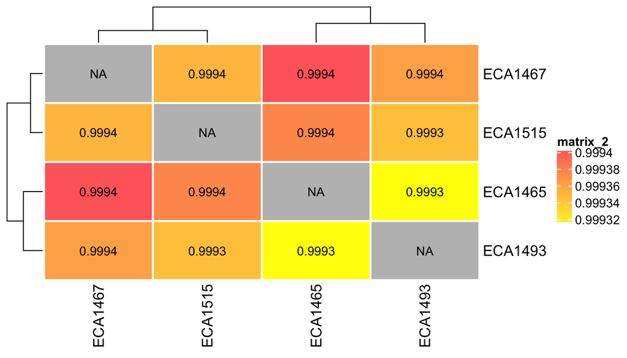